# Data Science Final project

## Data analysis

The average accuracy by listener’s country of origin is presented in Table 1 below. Although the scores do vary from country to country, the range of scores only reaches from 0.5621693 to 0.6856725, with an average accuracy of 0.6371769.

Table 1. The average hit rate of laugh identifications by listener's country of origin

| country | accuracy |
| --- | --- |
| Australia | 0.6527778 |
| Austria | 0.6733716 |
| Canada | 0.6064815 |
| China | 0.6439394 |
| Ecuador/Shuar | 0.5673401 |
| India | 0.5931373 |
| Indonesia | 0.6410256 |
| Iran | 0.6339031 |
| Japan | 0.6856725 |
| Korea | 0.6839080 |
| Netherlands | 0.6776486 |
| Peru (Rural) | 0.6075269 |
| Peru (Urban) | 0.6537037 |
| Qatar | 0.6370968 |
| Samoa | 0.5621693 |
| Singapore | 0.6194444 |
| Slovakia | 0.6400626 |
| South Africa/Zulu | 0.6005556 |
| Spain | 0.6539683 |
| Turkey | 0.6733716 |
| USA | 0.6736111 |

The influence of acoustic features on hit rates - or, rather, the apparent lack thereof - can be seen in Figure 1:

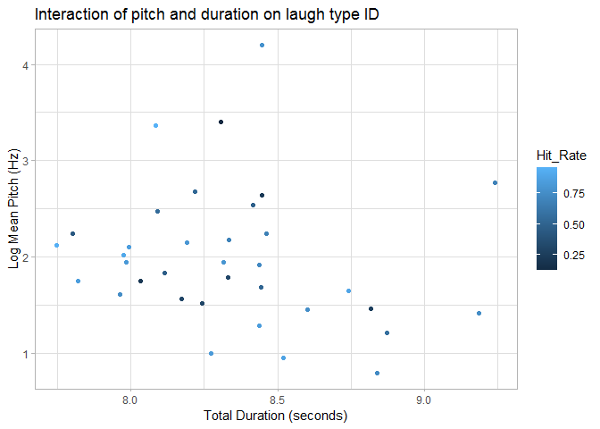

Note that, in Table 2 below, there is no significant difference in either pitch or duration, or their interaction, between the two stimulus conditions. That is, there is no acoustic difference between spontaneous and volitional laughter within these two measures. (A statement I better be able to change for my actual data.)

Table 2. Model of Laugh Condition by Pitch and Duration

| predictor | estimate | ci | statistic | p.value |
| --- | --- | --- | --- | --- |
| Intercept | 34.41 | $[-60.53$, $139.33]$ | 0.70 | .486 |
| Pitch | -4.04 | $[-16.44$, $7.23]$ | -0.69 | .489 |
| Duration | -39.42 | $[-104.27$, $12.31]$ | -1.34 | .179 |
| Pitch $\times$ Duration | 4.70 | $[-1.46$, $12.41]$ | 1.35 | .177 |

However, the human perceptual system is modified by more factors than just acoustic information. As seen in Table 3 below, the listener’s country of origin does impact whether or not the listener can correctly perceive a stimulus as spontaneous or volitional, $R^2 = .19$, $F(20, 863) = 10.24$, $p < .001$.

(Yes, I understand that’s not EXACTLY what these variables mean in the given dataset and that I’m talking about two different things, but the process of getting there is closest to what I’ll eventually be doing. Although there are a heck of a lot more countries than there will be conditions for what I’m doing.)

Table 3. Analysis of Variance of Hit Rate by Country

| predictor | estimate | ci | statistic | p.value |
| --- | --- | --- | --- | --- |
| Intercept | 0.65 | $[0.63$, $0.68]$ | 48.95 | < .001 |
| CountryAustria | 0.02 | $[-0.02$, $0.06]$ | 1.06 | .287 |
| CountryCanada | -0.05 | $[-0.08$, $-0.01]$ | -2.41 | .016 |
| CountryChina | -0.01 | $[-0.05$, $0.03]$ | -0.47 | .637 |
| CountryEcuador/Shuar | -0.09 | $[-0.12$, $-0.05]$ | -4.56 | < .001 |
| CountryIndia | -0.06 | $[-0.10$, $-0.02]$ | -3.21 | .001 |
| CountryIndonesia | -0.01 | $[-0.05$, $0.02]$ | -0.65 | .514 |
| CountryIran | -0.02 | $[-0.05$, $0.02]$ | -1.05 | .294 |
| CountryJapan | 0.03 | $[0.00$, $0.07]$ | 1.97 | .049 |
| CountryKorea | 0.03 | $[0.00$, $0.06]$ | 1.87 | .061 |
| CountryNetherlands | 0.02 | $[-0.01$, $0.06]$ | 1.41 | .158 |
| CountryPeru Rural | -0.05 | $[-0.08$, $-0.01]$ | -2.38 | .018 |
| CountryPeru Urban | 0.00 | $[-0.04$, $0.04]$ | 0.05 | .961 |
| CountryQatar | -0.02 | $[-0.05$, $0.02]$ | -0.82 | .410 |
| CountrySamoa | -0.09 | $[-0.13$, $-0.06]$ | -5.12 | < .001 |
| CountrySingapore | -0.03 | $[-0.07$, $0.00]$ | -1.86 | .063 |
| CountrySlovakia | -0.01 | $[-0.04$, $0.02]$ | -0.79 | .429 |
| CountrySouth Africa/Zulu | -0.05 | $[-0.08$, $-0.02]$ | -3.41 | .001 |
| CountrySpain | 0.00 | $[-0.04$, $0.04]$ | 0.06 | .949 |
| CountryTurkey | 0.02 | $[-0.02$, $0.06]$ | 1.06 | .287 |
| CountryUSA | 0.02 | $[-0.01$, $0.05]$ | 1.21 | .227 |

# References

Are what keeps breaking things I think, so I’d rather have some output than no output.